# Introduction to OLS

Linear Regression

Carolina Torreblanca

University of Pennsylvania

**Global Development**: Intermediate Topics in Politics, Policy, and Data

PSCI 3200 - Spring 2026

## Agenda

1. Why OLS?
2. Two things regression does
3. From difference-in-means to regression
4. Continuous predictors and the regression line
5. Playing God: simulating data
6. Adding controls
7. Running and interpreting OLS in R

# Why OLS?

## The Workhorse of Social Science

Almost every empirical paper in this course uses **linear regression**

- Comparing a treatment group to a control group? **Regression**
- Fixed effects? **Regression** with dummies as controls
- Fancy Difference-in-Differences? **Regression** with an interaction term
- Your final project? Likely **Regression**

## Why Should You Care?

For your final projects, you need to:

1. Come up with a research question
2. Answer it with data
3. Present and interpret your results

Today: what regression actually does, and how to use it.

# Two Things Regression Does

## Thing 1: Best Guess of Y

**“Given what I know about X, what is my best guess for Y?”**

- If I tell you a country’s GDP per capita is $10,000…
- What’s your best guess for its life expectancy?
- Regression gives a linear best guess

## Thing 2: How Much Does Y Change when X changes?

**“When X goes up by one unit, how much does Y change?”**

- If GDP per capita increases by one unit
- How many more years of life expectancy should we expect?
- This is the **slope**
- *Maybe* the causal effect of X on Y, depends…

# From Difference-in-Means to Regression

## Something You Already Know

Comparing a treatment group to a control group:

$$\text{Effect} = \overline{Y}_{treatment} - \overline{Y}_{control}$$

Remember the STAR experiment?

**We can estimate this with regression**

## Let’s Prove It

```r
library(ggplot2)
library(modelsummary)

# Simulate an experiment
set.seed(42)
experiment <- data.frame(
  treatment = c(rep(0, 50), rep(1, 50))
)
experiment$outcome <- 10 + 3 * experiment$treatment + rnorm(100, 0, 2)
```

**Method 1: Difference in means**

```r
mean(experiment$outcome[experiment$treatment == 1]) -
  mean(experiment$outcome[experiment$treatment == 0])
```

```
[1] 3.272746
```

**Method 2: Regression**

```r
coef(lm(outcome ~ treatment, data = experiment))
```

```
(Intercept)   treatment
   9.928656    3.272746
```

## Same Answer

- The intercept = the control group mean
- The slope on `treatment` = the difference in means
- **Regression with a binary variable IS a difference in means**

## Why Not Just Use Difference-in-Means for Everything?

Because the real world is more complicated:

- What if your key variable isn’t binary? (GDP is continuous)
- What if you need to **control** for something? (Education, geography…)
- What if you want to compare across **multiple groups** at once?
- Regression handles all of this. Difference-in-means can’t

# The Regression Line

## Now With a Continuous Variable

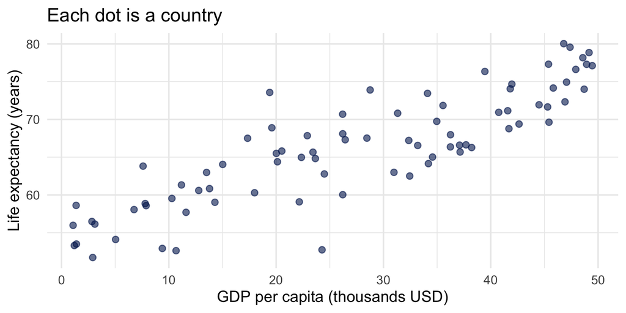

```r
set.seed(42)
n <- 80
countries <- data.frame(
  gdp = runif(n, 1, 50)  # GDP per capita in thousands of USD
)
countries$life_exp <- 55 + 0.4 * countries$gdp + rnorm(n, 0, 4)

ggplot(countries, aes(x = gdp, y = life_exp)) +
  geom_point(size = 3, alpha = 0.6, color = "#011F5B") +
  labs(x = "GDP per capita (thousands USD)",
       y = "Life expectancy (years)",
       title = "Each dot is a country") +
  theme_minimal(base_size = 18)
```

There’s clearly a pattern. But what line best captures it?

## Which Line?

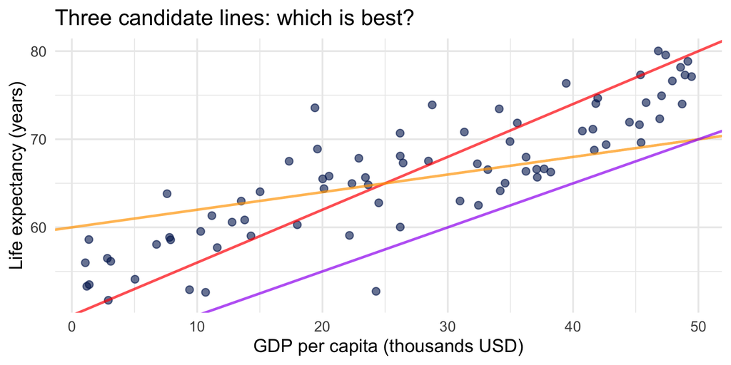

We need a rule for “best line” That rule is **OLS**.

## The Equation

A line needs two numbers: an **intercept** and a **slope**

$$Y_i = \alpha + \beta X_i + \epsilon_i$$

- $\alpha$ (**intercept**): value of $Y$ when $X = 0$
- $\beta$ (**slope**): how much $Y$ changes when $X$ goes up by one unit

## What About $\epsilon$?

$$Y_i = \alpha + \beta X_i + \epsilon_i$$

Life expectancy depends on a million things: healthcare, diet, war, genetics, luck…

- We’re only using GDP to predict life expectancy
- Everything else lands in $\epsilon_i$ (the **error term**)
- The error is the **gap between our simple model and complicated reality**

## How OLS Picks the Line

For each data point, the line makes a **prediction**:

$$\text{Prediction for country } i = \alpha + \beta X_i$$

The **residual** is how far off that prediction is:

$$\text{Residual}_i = \text{Observed } Y_i - \text{Prediction}_i$$

## Minimizing Residuals

**OLS** picks the $\alpha$ and $\beta$ that make the residuals as small as possible.

Specifically, it minimizes the **sum of squared residuals**:

$$SSR = \sum_{i=1}^{N} \text{Residual}_i^2$$

- Why squared? So positive and negative misses don’t cancel out
- And big misses are penalized more than small ones

## Visualizing Residuals

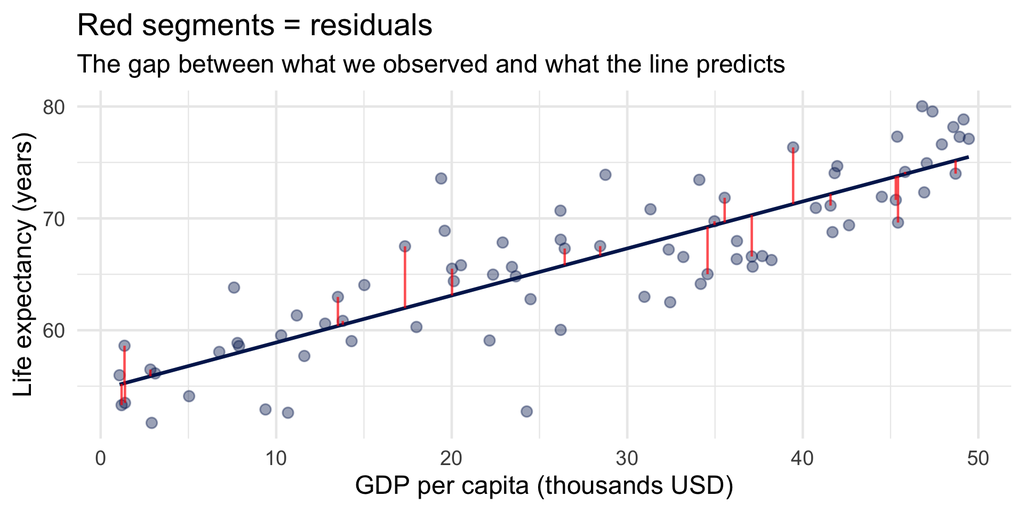

OLS = the line that makes these red segments as small as possible (in total).

# Playing God

## A Simulation

Imagine you are God. You get to decide how the world works

You decree: **life expectancy = 55 + 0.4 $\times$ GDP**

That’s the general rule. But you’re a generous God, each country gets a little bit of **free will** (randomness).

**Question:** If a researcher only sees the data can they figure out what you decided?

## You Create the World

```r
set.seed(123)

# GOD'S RULE (the truth no one can see)
true_intercept <- 55
true_slope     <- 0.4

# Generate data for 100 countries
n <- 100
gdp <- runif(n, 1, 50)  # GDP in thousands of USD
life_exp <- true_intercept + true_slope * gdp + rnorm(n, 0, 20)

god_data <- data.frame(gdp, life_exp)
```

Now let’s pretend we’re a researcher who **only sees the data**, not the rule.

## OLS Tries to Recover the Truth

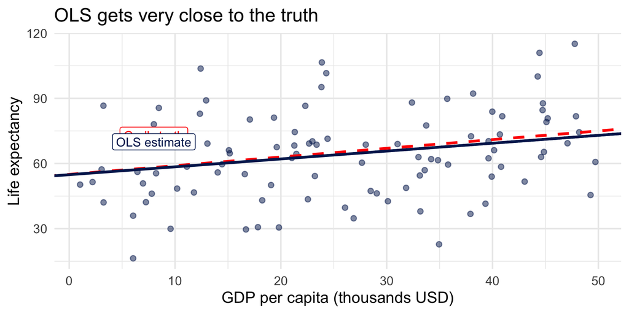

```r
fit <- lm(life_exp ~ gdp, data = god_data)

ggplot(god_data, aes(x = gdp, y = life_exp)) +
  geom_point(alpha = 0.5, color = "#011F5B") +
  geom_abline(intercept = true_intercept, slope = true_slope,
              color = "red", linewidth = 1.5, linetype = "dashed") +
  geom_abline(intercept = coef(fit)[1], slope = coef(fit)[2],
              color = "#011F5B", linewidth = 1.5) +
  annotate("label", x = 8, y = 73, label = "God's truth",
           color = "red", size = 5) +
  annotate("label", x = 8, y = 70, label = "OLS estimate",
           color = "#011F5B", size = 5) +
  labs(x = "GDP per capita (thousands USD)", y = "Life expectancy",
       title = "OLS gets very close to the truth") +
  theme_minimal(base_size = 18)
```

## How Close?

```r
# What God decided
c(true_intercept = true_intercept, true_slope = true_slope)
```

```
true_intercept     true_slope
          55.0            0.4
```

```r
# What OLS found
coef(fit)
```

```
(Intercept)         gdp
 54.8574688   0.3633341
```

Not perfect because of the free will (randomness) but very close.

## Different Worlds, Same Rule

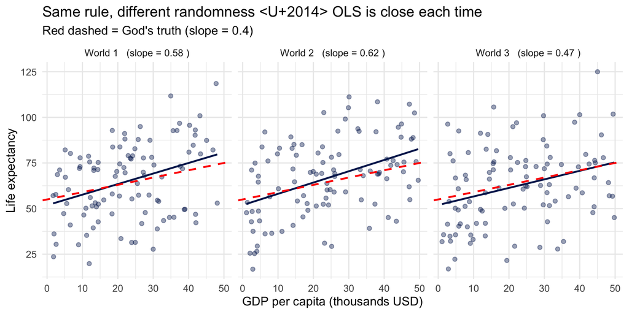

```r
par_df <- data.frame()
for (world in 1:3) {
  set.seed(world * 10)
  g <- runif(n, 1, 50)
  le <- true_intercept + true_slope * g + rnorm(n, 0, 20)
  f <- lm(le ~ g)
  par_df <- rbind(par_df, data.frame(
    gdp = g, life_exp = le,
    world = paste("World", world,
                  "  (slope =", round(coef(f)[2], 2), ")")
  ))
}

ggplot(par_df, aes(x = gdp, y = life_exp)) +
  geom_point(alpha = 0.4, color = "#011F5B") +
  geom_smooth(method = "lm", se = FALSE, color = "#011F5B", linewidth = 1) +
  geom_abline(intercept = true_intercept, slope = true_slope,
              color = "red", linewidth = 1, linetype = "dashed") +
  facet_wrap(~world) +
  labs(x = "GDP per capita (thousands USD)", y = "Life expectancy",
       title = "Same rule, different randomness — OLS is close each time",
       subtitle = "Red dashed = God's truth (slope = 0.4)") +
  theme_minimal(base_size = 14)
```

## OLS Works… When the Truth Is Linear

- We made a **linear** rule, and OLS (which fits a **line**) recovered it
- But what if the truth isn’t linear?
- What if God decided something more complicated?

## What If the Truth Is Curved?

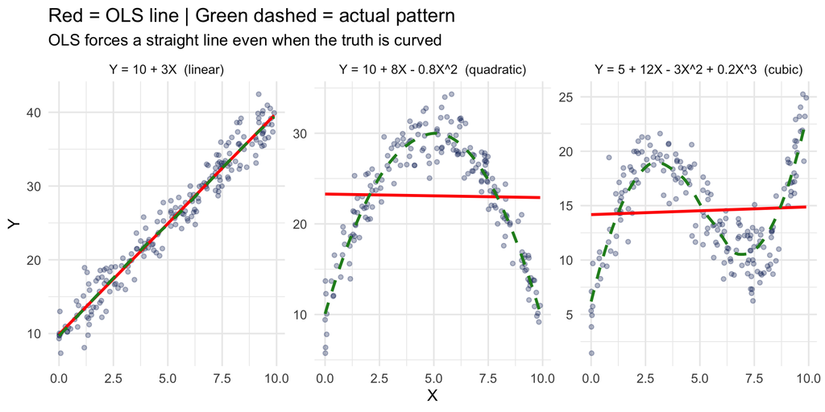

```r
set.seed(42)
x_sim <- runif(200, 0, 10)

# Three different truths — with clear, big coefficients
linear_y    <- 10 + 3 * x_sim + rnorm(200, 0, 2)
quadratic_y <- 10 + 8 * x_sim - 0.8 * x_sim^2 + rnorm(200, 0, 2)
cubic_y     <- 5 + 12 * x_sim - 3 * x_sim^2 + 0.2 * x_sim^3 + rnorm(200, 0, 2)

sim_worlds <- rbind(
  data.frame(x = x_sim, y = linear_y,    truth = "Y = 10 + 3X  (linear)"),
  data.frame(x = x_sim, y = quadratic_y, truth = "Y = 10 + 8X - 0.8X²  (quadratic)"),
  data.frame(x = x_sim, y = cubic_y,     truth = "Y = 5 + 12X - 3X² + 0.2X³  (cubic)")
)

ggplot(sim_worlds, aes(x = x, y = y)) +
  geom_point(alpha = 0.3, color = "#011F5B", size = 1.5) +
  geom_smooth(method = "lm", se = FALSE, color = "red", linewidth = 1.2) +
  geom_smooth(method = "loess", se = FALSE, color = "forestgreen",
              linewidth = 1.2, linetype = "dashed") +
  facet_wrap(~truth, scales = "free_y") +
  labs(x = "X", y = "Y",
       title = "Red = OLS line | Green dashed = actual pattern",
       subtitle = "OLS forces a straight line even when the truth is curved") +
  theme_minimal(base_size = 14)
```

## All Models Are Wrong, But Some Are Useful

- OLS **always** fits a straight line
- When the truth is linear, it works great
- When the truth is curved, the line **misses the pattern**
- In practice, OLS is surprisingly robust unless things are dramatically nonlinear
- We mostly use OLS to **estimate associations and marginal effects**, not to predict

# Adding Controls

## The Problem: Omitted Variables

What if we left something important out of the model?

Let’s play God again but this time with **two** variables that matter

Life expectancy is going to depend on both GDP and average education BUT education depends on gdp as wel

## Visualize the DAG

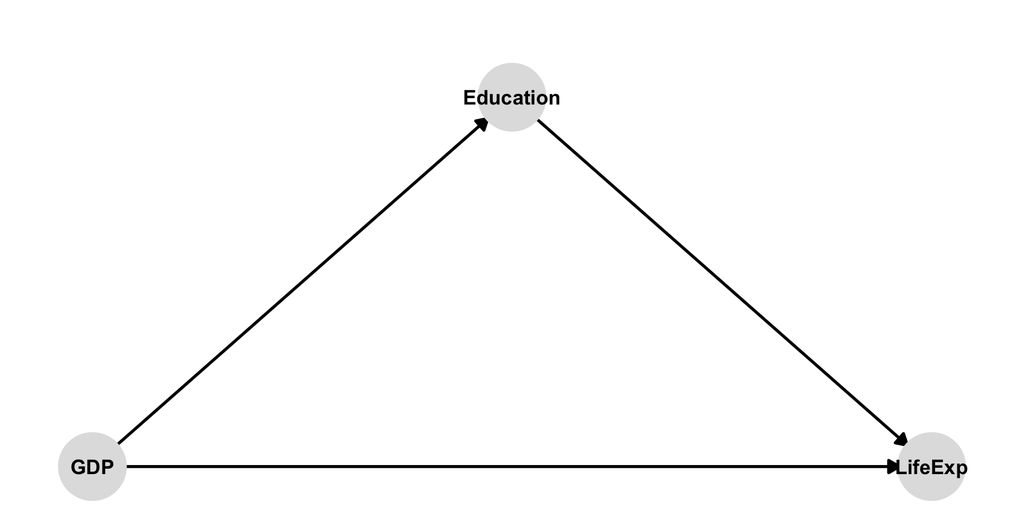

## God’s New Rule

```r
set.seed(42)
n_c <- 80
ctrl <- data.frame(gdp = runif(n_c, 1, 50)) # GDP in thousands

# Education is correlated with GDP (richer countries → more education)
ctrl$education <- 2 + 0.4 * ctrl$gdp + rnorm(n_c, 0, 3)

# God's truth: BOTH matter, but education matters a LOT
ctrl$life_exp <- 45 + 0.2 * ctrl$gdp + 1.5 * ctrl$education + rnorm(n_c, 0, 2)
```

God decided:

- GDP matters a little (true slope = **0.2**)
- Education matters a lot (true slope = **1.5**)
- But GDP and education are **correlated**

## What Happens If We Forget Education?

```r
model_no_ctrl   <- lm(life_exp ~ gdp, data = ctrl)
model_with_ctrl <- lm(life_exp ~ gdp + education, data = ctrl)

modelsummary(list("Life Exp" = model_no_ctrl,
                  "Life Exp" = model_with_ctrl),
  estimate  = "{estimate}{stars} ({std.error})",
  statistic = NULL,
  gof_omit = 'IC|RMSE|Log|F|R2$|Std.')
```

|  | Life Exp | Life Exp |
| --- | --- | --- |
| (Intercept) | 47.854*** (1.089) | 45.131*** (0.427) |
| gdp | 0.808*** (0.035) | 0.170*** (0.032) |
| education |  | 1.535*** (0.070) |
| Num.Obs. | 80 | 80 |
| R2 Adj. | 0.871 | 0.982 |

## What Just Happened?

- **Without education**: the GDP coefficient is inflated
- **With education**: it **drops dramatically**, closer to God’s truth (0.2)
- Why? GDP and education are correlated
- GDP was getting credit for education’s work
- This is **omitted variable bias**

## Interpretation With Controls

**Without controls:**

“A $1,000 increase in GDP is associated with a 0.81 year increase in life expectancy.”

**With controls:**

“Holding education constant, a $1,000 increase in GDP is associated with a 0.17 year increase.”

“Holding constant” = comparing countries with the **same** education level.

# Controls and Causality

## Does Controlling Make It Causal?

- Remember the causality lectures: a causal effect is about the **counterfactual**
- “What **would have happened** to this country if its GDP were higher, *but everything else was held constant?*”

## When Can We Make Causal Claims?

We need a **good reason** for why the contrasts we’re estimating are causal.

- That reason always comes back to the same thing: the **average counterfactual is valid**
- The comparison group is a good stand-in for what would have happened without the treatment
- This is an assumption about the **world**, not about the model

# Running OLS in R

## The Full Workflow

```r
# Fit the model
model <- lm(life_exp ~ gdp, data = countries)

# See the full output
summary(model)
```

```
Call:
lm(formula = life_exp ~ gdp, data = countries)

Residuals:
     Min       1Q   Median       3Q      Max
-12.1672  -2.1310   0.4795   2.3804  10.7122

Coefficients:
            Estimate Std. Error t value            Pr(>|t|)
(Intercept)  54.6994     0.8775   62.33 <0.0000000000000002 ***
gdp           0.4204     0.0282   14.91 <0.0000000000000002 ***
---
Signif. codes:  0 '***' 0.001 '**' 0.01 '*' 0.05 '.' 0.1 ' ' 1

Residual standard error: 3.758 on 78 degrees of freedom
Multiple R-squared:  0.7402,    Adjusted R-squared:  0.7369
F-statistic: 222.2 on 1 and 78 DF,  p-value: < 0.00000000000000022
```

## What Each Piece Means

- **Estimate**: the intercept and slope are our best guesses of $\alpha$ and $\beta$
- **Std. Error**: the standard deviation of the sampling distribution of our estimates
- **Pr(>|t|)**: how likely we’d see an estimate this large if the true value were zero
- **R-squared**: fraction of variation in $Y$ explained by $Xs$ (0 = nothing, 1 = everything)

## Interpreting the Slope

```r
coef(model)
```

```
(Intercept)         gdp
 54.6994253   0.4204093
```

**Interpretation:** “A one unit ($1k) increase in GDP per capita is associated with a 0.42 year increase in life expectancy.”

Or: “A **$10k** increase in GDP is associated with a **4.2** year increase in life expectancy.”

## Clean Output with `modelsummary()`

```r
modelsummary(model,
  estimate  = "{estimate}{stars} ({std.error})",
  statistic = NULL,
  gof_omit = 'IC|RMSE|Log|F|R2$|Std.')
```

|  | Model 1 |
| --- | --- |
| (Intercept) | 54.699*** (0.878) |
| gdp | 0.420*** (0.028) |
| Num.Obs. | 80 |
| R2 Adj. | 0.737 |

## Visualize the Line

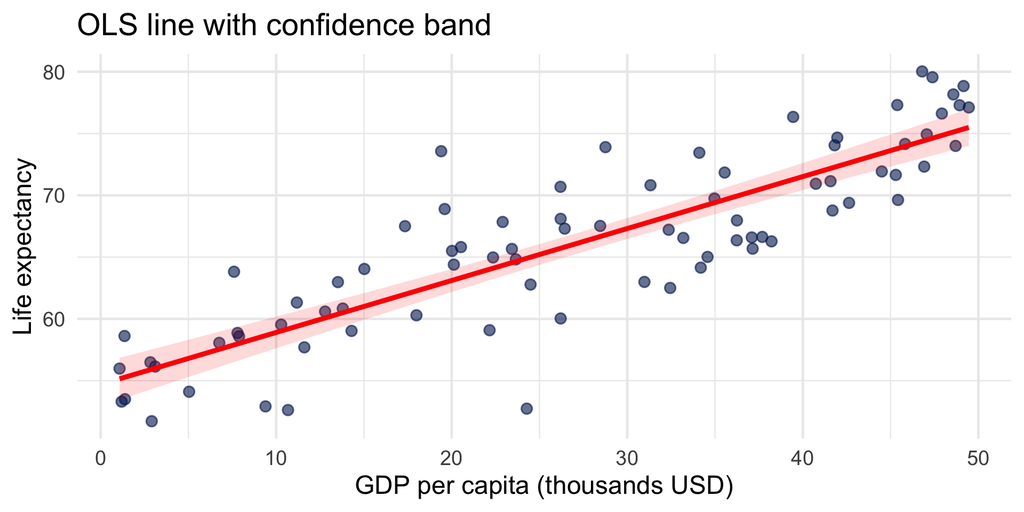

```r
ggplot(countries, aes(x = gdp, y = life_exp)) +
  geom_point(size = 3, alpha = 0.6, color = "#011F5B") +
  geom_smooth(method = "lm", color = "red", fill = "red", alpha = 0.15) +
  labs(x = "GDP per capita (thousands USD)", y = "Life expectancy",
       title = "OLS line with confidence band") +
  theme_minimal(base_size = 18)
```

# Wrapping Up

## What Regression Gives You

1. A **best (linear) guess** of $Y$ for any value of $X$ (prediction)
2. A **slope** that tells you how $Y$ changes when $X$ changes (association)
3. The ability to **control** for other variables, or hold them constant

## What Regression Does NOT Give You

- Causality does not come from the model, it comes from the **persuasivness of your research design**
- A theory of the world! Controls only help if you’ve identified the right confounders (think about your DAGs!)

https://carolina-torreblanca.github.io/psci3200-globaldev-main/